# AI Skills in Action: From Research Files to Presentation-ready Slides

A hands-on session using an AI skill developed with DECDI branding guidelines

Ankriti Singh

DECDI, The World Bank

2026-09-21

## Objective

Produce a **well-structured, presentation-ready slide deck**.

You can start from:

- Research materials such as a manuscript, results, code, or a reproducibility package. The more relevant material you provide, the better.
- An existing slide deck that needs structural improvement or rebranding.

## Before we begin: prerequisites

- **Training slides:** [https://bit.ly/ai-slide-skills](https://dime-worldbank.github.io/ai-research-training/sessions/ai-skills-slides/slides/)
- **Visual Studio Code** installed from the Software Center
- One AI assistant signed in within VS Code:
  - GitHub Copilot with the Copilot Chat extension and a Claude model
  - Claude Code extension linked to a personal or team account
- Your own existing project, or the demo project: download [here](https://github.com/dime-worldbank/ai-research-training/raw/refs/heads/main/sessions/ai-skills-slides/materials/demo-projects.zip)
- The **prepare-slides AI skill:** download [here](https://github.com/dime-worldbank/ai-research-training/releases/latest/download/prepare-slides.zip)

# Why use a skill?

## What is an AI skill?

An AI skill is a folder of instructions and resources that an AI agent reads to perform a specialized task more consistently.

It is triggered when:

- The agent recognizes that the task matches the skill description
- The user explicitly tells the agent to read and follow `SKILL.md`

The skill adds task-specific workflow and resources to the agent’s general capabilities.

## A skill makes the workflow reusable

| A prompt on its own | A prompt using the skill |
| --- | --- |
| Must explain the process each time | A short request triggers the established process |
| May not include the current templates or brand files | Templates, logos, and standards are packaged with the instructions |
| Success depends on what the agent remembers to check | Approval and quality checks are built into the workflow |

# Why use the `prepare-slides` skill?

## The same research often becomes several different presentations

Think about how many times you prepare slides using the same research:

- For government policymakers
- For an academic or research audience
- For an internal review or project meeting
- For a conference, workshop, or training

Each time, you must select the story, rewrite the content, adapt the figures, apply the template, and check the formatting.

**Turning research into slides becomes a second production workflow.**

## `prepare-slides` makes that workflow reusable

- Start from the same manuscript, results, figures, or existing deck
- Adapt the story and level of detail for the intended audience
- Review the outline and visual choices before production
- Create or improve slides in PowerPoint, Quarto, or Beamer
- Apply DEC/World Bank branding and check the rendered output

**Spend your time tailoring the message, not rebuilding the presentation.**

## Architecture of `prepare-slides` skill

```
skills/
├── README.md             how a person installs and requests the skill
└── prepare-slides/
    ├── SKILL.md          workflow and approval gates
    ├── references/       structure, evidence, review, and format standards
    ├── branding/         canonical colors and approved logos
    └── assets/           working format-specific starters
```

- `README.md` is for the person using the skill
- `SKILL.md` is for the AI agent
- `branding/` is the source of truth that feeds the starter assets. This was built from the [DECDI branding guidelines](https://www.canva.com/design/DAG_uu89IfA/9M6MXACvYKjn4wmVqjc5Lg/view?utm_content=DAG_uu89IfA&utm_campaign=designshare&utm_medium=link&utm_source=viewer#16.)

## The agent loads only what the task needs

**Always**

`SKILL.md`

Selects the service and controls the two phases.

**When relevant**

`references/`

Adds detailed standards for the current task.

**During production**

`assets/`

Provides the starter for the selected format.

## References guide decisions; assets become working files

### References

- `slide-structure.md`
- `figure-table-guidelines.md`
- `deck-review-checklist.md`
- `decdi-branding.md`
- `format-conventions.md`

The agent reads the relevant files. They are not copied into the output.

### Assets

- `quarto/`
- `beamer/`
- `pptx/`

The agent copies or uses the selected starter during production.

# How the skill works

## Start with project materials or an existing deck

### 1. Create a new deck from project materials

Provide the manuscript, results, code, figures, tables, and project notes. The more relevant material the agent can access, the better.

### 2. Improve an existing deck

Improve the story, content, layouts, visuals, and branding. If the content is already strong, request rebranding only.

Supporting materials help the agent verify claims and improve either pathway.

## The author approves the plan before production begins

### 1. Phase 1: Proposal

The agent reviews the materials and proposes the story, slide outline, and visual alternatives.

### 2. Author review

The author revises or approves the story and visual choices, then selects the presentation format and logo.

### 3. Phase 2: Production

The agent creates or revises the deck, renders it, inspects the output, and fixes material problems.

**Production begins only after the author approves the plan.**

## Phase 1 turns source material into decisions

For a new deck or substantial improvement, the agent provides:

1. A source-use summary: each primary file, its role, and whether it was read, partially read, or unreadable
2. A short narrative summary
3. A slide-by-slide outline
4. Visual alternatives for figures and tables
5. An assessment of the existing deck, when relevant
6. A prefilled Author Decision Form

**No presentation files are created or edited during Phase 1.**

## Every proposal starts with a source-use summary

**Primary source files:**

- `paper.pdf` (manuscript, AER 2022): read via extracted text: abstract, intro, data/design, results, conclusion
- `project-materials/tabfig/figs/*.pdf`: inspected as rendered images; all used figures are the manuscript authors’ own exhibits

**Supporting materials:** results files and code, consulted to verify figures and table values, not to source new claims

**No source-access limitations.**

## A Phase 1 proposal shows the proposed outline

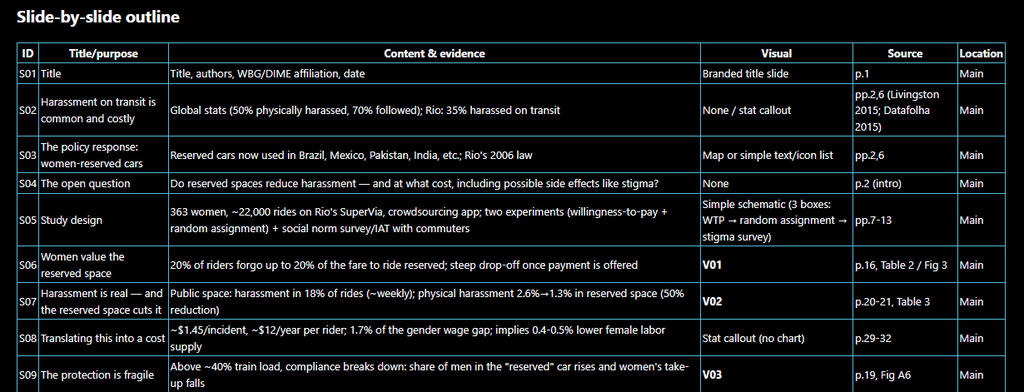

## The proposal also records visual decisions

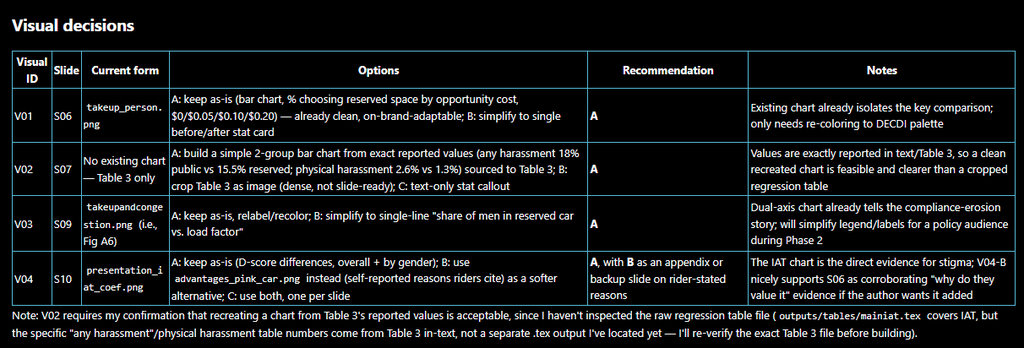

## The agent picks visuals in a fixed order, not by what looks nice

1. **What’s the point?** the one claim this figure/table needs to prove
2. **Does it belong in the main deck?** or is it just supporting detail?
3. **What evidence do we actually have?** real data/numbers only, no guessing
4. **What’s the simplest way to show it?** one number, a bar chart, a table…
5. **Which layout fits?** one visual, visual + text, or a side-by-side comparison

**Visual variety is never the reason to choose a chart.**

## The author can approve, edit, or request alternatives

[output not shown]

The author can respond in ordinary language and ask for additional alternatives before or after production.

## Phase 2 follows one of three routes

**Build**

Copy the selected starter and create the approved deck.

**Improve**

Edit the existing source or reconstruct it in the starter, based on the approved review.

**Rebrand**

Edit a copy of the existing source using the starter’s visual system.

After reviewing the output, the author can request additional changes. The original source remains unchanged unless in-place editing was explicitly requested.

## Phase 2 keeps a record of what was approved and built

Every Phase 2 run keeps a `production-decisions.txt` file beside the deck:

- The completed Author Decision Form (service, format, visual choices, logo)
- Each slide’s final title, visual pattern, and asset path
- Any figure-generation script, inputs, and parameters used

On a later request for the same deck, the agent reads this file first and reuses prior approvals instead of asking again.

You’ll see this file appear in your exercise folder after Phase 2. It’s expected, not a build artifact to delete.

# Limitations

## Less source material means more uncertainty and more review

Without the manuscript, results, code, notes, or data, the agent must limit its checks and state what it cannot verify.

With only a manuscript, it may adapt exact reported values or leave a placeholder. It should not invent missing values.

Large or inconsistent decks with missing source files require more reconstruction, rendering, and author review.

More relevant source material improves what the agent can verify and usually reduces revision time.

## Recreated exhibits may not update automatically

If the agent recreates a table or chart without the original code and data, the exhibit may be hard-coded. It will not update automatically when the results change.

If updateability matters, request:

- Charts and tables generated from the provided code and data
- Editable, reusable source files
- Clear links to the underlying data
- Instructions for rerendering the deck

When code or data are unavailable, an updated manuscript can be used to regenerate the deck, but the author still needs to review every recreated exhibit.

# Hands-on exercise

## Choose your starting point

### Option 1: Use your own project

Work with a manuscript, results, code, figures, or an existing research project already on your computer.

### Option 2: Use the demo project

Download the prepared exercise folder:

**[Download the demo project](https://github.com/dime-worldbank/ai-research-training/raw/refs/heads/main/sessions/ai-skills-slides/materials/demo-projects.zip)**

Both routes use the same skill and approval workflow.

## If you are using your own project

1. Download and unzip the [prepare-slides skill](https://github.com/dime-worldbank/ai-research-training/releases/latest/download/prepare-slides.zip)
2. Create `.agents/skills/` at the project root
3. Copy the complete `prepare-slides/` folder into it

```
your-project/
├── .agents/
│   └── skills/
│       └── prepare-slides/
│           ├── SKILL.md
│           ├── references/
│           ├── branding/
│           └── assets/
├── manuscript.pdf
├── results/
└── other-project-files/
```

## If you are using the demo project

1. Download and unzip the demo project. The demo-project folder has 2 sub-folders: `exercise-1` and `exercise-2`. We will use the `exercise-1` to create slides from scratch.
2. Download and unzip the [prepare-slides skill](https://github.com/dime-worldbank/ai-research-training/releases/latest/download/prepare-slides.zip)
3. Copy `prepare-slides/` into the exercise-1’s `.agents/skills/` folder

```
exercise-1/
├── .agents/
│   └── skills/
│       └── prepare-slides/
│           └── SKILL.md
└── irrigation-project/
```

Keep the complete skill folder even though only `SKILL.md` is shown here.

## Open the project in VS Code and check the settings

1. Select **File → Open Folder**
2. Open your project folder (or `exercise-1` folder), not an individual file
3. Open the Copilot Chat or Claude Code panel
4. If using Claude Code, install the **Claude Code extension** and sign in

If you see a Claude CLI error when using Copilot chat, start a new chat and confirm that **Local** is selected.

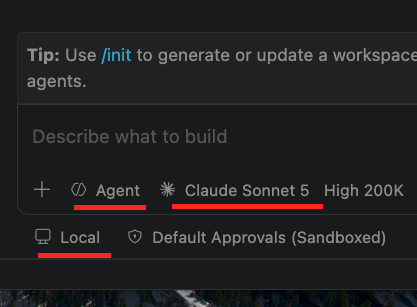

## Ask the agent to prepare the slides

```
Read prepare-slides/SKILL.md and use it to preapre a 30-minute beamer
presentation using the relevant research materials in this project.
The audience is government policymakers. Focus on the main findings and policy
implications.
```

## Review the source inventory and proposed story

Check:

- Did the agent identify the relevant source files?
- Did it state what it could not verify?
- Do the slide titles tell a coherent story?
- Does the proposed main deck fit the presentation time?
- Are technical details moved to the appendix when appropriate?
- Are the visual alternatives faithful to the available evidence?

Correct the inventory or narrative before approving production.

## Approve the outline or ask for alternatives

```
Outline: Approve with changes

Slide changes:
- S__: [your requested change]

Visual decisions:
- V01: Show options A and B side by side
- V02: Keep the recommended option

Format: [PowerPoint / Quarto / Beamer]
Logo family: [DECDI/DEC / World Bank Group]
```

You can ask the agent to revise the outline or present additional visual alternatives before choosing.

## Inspect the rendered deck

- Is the narrative still the one you approved?
- Are the claims traceable to the supplied materials?
- Are figures and tables faithful, legible, and easy to interpret?
- Is the branding consistent?
- Are sources and notes concise?
- Is anything clipped, crowded, or unexpectedly wrapped?

Ask for corrections before accepting the output.

# Optional exercise 2: Improve an existing deck

## This deck has slides, but it is not presentation-ready

```
exercise-2/
├── .agents/
│   └── skills/
│       └── prepare-slides/
│           └── SKILL.md
└── sms-project/
```

**Notes:** The exercise deck is intentionally inconsistent and text-heavy.

## Ask for improvement and review the proposal

```
Read the prepare-slides SKILL.md and follow it.
Improve the existing slide deck using the materials in the folder.
The resulting slides should be in the latex-beamer format.
```

## Approve the priorities, then inspect the result

Before production:

- Approve or revise the proposed narrative
- Choose the most important slide changes
- Approve visual alternatives
- Confirm whether you want improvement or rebranding only
- Confirm the logo family

After production, check that the deck was improved rather than merely recolored and that every approved change was implemented.

# Apply it to your project

## Install the complete folder once per project

1. Download and unzip the [prepare-slides skill](https://github.com/dime-worldbank/ai-research-training/releases/latest/download/prepare-slides.zip)
2. Create `.agents/skills/` at the project root if needed
3. Copy the complete `prepare-slides/` folder into it

```
your-project/
└── .agents/
    └── skills/
        └── prepare-slides/
            ├── SKILL.md
            ├── references/
            ├── branding/
            └── assets/
```

`.agents/skills/` is a convention. Use your agent’s preferred skills directory if it has one.

## Your prompt needs a task and source paths

**Create**

> Create a 30-minute presentation using the relevant files in `[YOUR PROJECT FOLDER]`.

**Improve**

> Improve `[YOUR DECK]` using `[SUPPORTING MATERIALS]` to check the content.

**Rebrand**

> Rebrand `[YOUR DECK]` using the bundled DECDI template and branding guidance. Preserve its content arrangement and order.

## The author approves; the agent produces and checks

```
source material
      ↓
Phase 1 proposal
      ↓
author decisions
      ↓
Phase 2 production
      ↓
rendered inspection
```

The approval gate is where the author controls the story, evidence, format, and visual choices.

## Spend less time formatting. Spend more time strengthening the message.

**Reuse the same research materials to produce clearer, audience-specific decks with a consistent workflow.**

## Thank you

Questions and discussion

The `prepare-slides` skill is a work in progress. Feedback from real projects is appreciated and will help improve it.

[figure not shown]

[figure not shown]

Using AI to Automate Research Outputs